# Introduction to Python Data Processing and Visualisation

### Adam Ruszkowski

29/09/2017

### Purpose

- In this presentation, we'll briefly cover some of the methods that can be used to process and visualise data in Python
- This is intended to be **a brief overview only** - code examples are included, but will not be explained in great detail

### Why Python?

- Python allows us to quickly and reproducibly process data
- The syntax of the language is (relatively!!) easy to understand
- Numerous modules exist which take out some of the hard work

### Modules

- Python allows users to group together defined objects, variables and functions into a file (or several files) so that they can be used in other programs
- These are referred to as "modules"
- We will use several specialised modules which have to be installed separately by the user:
  - `numpy`
  - `matplotlib/seaborn`
  - `plotly`
- We have to `import` these into our program

```python
import matplotlib.pyplot as plt
%matplotlib inline
import seaborn as sns
sns.set_style('darkgrid')
sns.set_context('poster')
import pandas as pd
```

## Data Processing

### Pandas

- Pandas is a Python module which describes itself as:

  > an open source, BSD-licensed library providing high-performance, easy-to-use data structures and data analysis tools for the Python programming language.
- It processes data quickly, and has good interactions with Excel and CSV files
- Generally, data is imported into a `DataFrame`, which is a bit like an Excel worksheet - it uses columns and row to store data in a tabular format
- Mostly we refer to columns by their names - note that using the correct case is critical (`sitename` is not the same as `SiteName`)

### Reading in Data

- Reading in data from a CSV file is very straightforward
- We could read in all of the locations at once, but for now we'll pick just one

```python
original_data = pd.read_csv('VBV_Data\VBV_20170131_JTC00567_shay_2940.csv', low_memory=False)
original_data.head(15)
```

|  | RecordedDataTime | SiteName | SpeedMPH | Class | Length(Metres) | Chasis Ht | Info | Gap | Lane | Direction |
| --- | --- | --- | --- | --- | --- | --- | --- | --- | --- | --- |
| 0 | 2016-06-01 00:01:04 | JTC00567 | 68 | 2 | 4 | NaN | Car / Small Van <5.2 metres | NaN | 1 | S |
| 1 | 2016-06-01 00:01:09 | JTC00567 | 64 | 2 | 4 | NaN | Car / Small Van <5.2 metres | 49.0 | 1 | S |
| 2 | 2016-06-01 00:01:12 | JTC00567 | 57 | 5 | 18 | NaN | Rigid HGV + Trailer / Standard Articulated (Ca... | NaN | 1 | N |
| 3 | 2016-06-01 00:01:25 | JTC00567 | 76 | 4 | 6 | NaN | Rigid HGV / Large Van | 158.0 | 1 | S |
| 4 | 2016-06-01 00:02:30 | JTC00567 | 58 | 4 | 8 | NaN | Rigid HGV / Large Van | NaN | 2 | N |
| 5 | 2016-06-01 00:02:30 | JTC00567 | 57 | 5 | 16 | NaN | Rigid HGV + Trailer / Standard Articulated (Ca... | 774.0 | 1 | N |
| 6 | 2016-06-01 00:03:05 | JTC00567 | 53 | 5 | 15 | NaN | Rigid HGV + Trailer / Standard Articulated (Ca... | 1002.0 | 1 | S |
| 7 | 2016-06-01 00:04:41 | JTC00567 | 58 | 5 | 18 | NaN | Rigid HGV + Trailer / Standard Articulated (Ca... | 950.0 | 1 | S |
| 8 | 2016-06-01 00:04:44 | JTC00567 | 77 | 2 | 4 | NaN | Car / Small Van <5.2 metres | 1335.0 | 1 | N |
| 9 | 2016-06-01 00:04:53 | JTC00567 | 66 | 2 | 3 | NaN | Car / Small Van <5.2 metres | 110.0 | 1 | S |
| 10 | 2016-06-01 00:04:58 | JTC00567 | 57 | 5 | 16 | NaN | Rigid HGV + Trailer / Standard Articulated (Ca... | 138.0 | 1 | N |
| 11 | 2016-06-01 00:05:08 | JTC00567 | 51 | 5 | 16 | NaN | Rigid HGV + Trailer / Standard Articulated (Ca... | 146.0 | 1 | S |
| 12 | 2016-06-01 00:05:10 | JTC00567 | 52 | 2 | 4 | NaN | Car / Small Van <5.2 metres | 21.0 | 1 | S |
| 13 | 2016-06-01 00:05:50 | JTC00567 | 61 | 2 | 4 | NaN | Car / Small Van <5.2 metres | 507.0 | 1 | N |
| 14 | 2016-06-01 00:06:04 | JTC00567 | 48 | 5 | 17 | NaN | Rigid HGV + Trailer / Standard Articulated (Ca... | 141.0 | 1 | N |

### Processing Data

- Once we have the data imported into `pandas`, we can start to manipulate it.
- Python (and `pandas`) can manipulate dates and times, if they're the correct kind of object.
- We can convert the strings, and calculate hourly counts in a few lines of code

```python
# Create a "Count" column, which will be 1 for each record to begin wth
original_data['Count'] = 1

# Make sure dates are used as dates, and set them as the index so we can summarise
original_data['DateTime'] = pd.to_datetime(original_data['RecordedDataTime'])
original_data.set_index('DateTime', inplace=True)

# Work out the vehicle count per class and direction for each hour
hourly_counts = original_data.groupby([pd.TimeGrouper('1H'), 'Info'])['Count'].count().reset_index()
hourly_counts.head(15)
```

|  | DateTime | Info | Count |
| --- | --- | --- | --- |
| 0 | 2016-06-01 00:00:00 | Car / Small Van <5.2 metres | 48 |
| 1 | 2016-06-01 00:00:00 | Car / Small Van <5.2 metres with Trailer | 2 |
| 2 | 2016-06-01 00:00:00 | Rigid HGV + Trailer / Standard Articulated (Ca... | 27 |
| 3 | 2016-06-01 00:00:00 | Rigid HGV / Large Van | 11 |
| 4 | 2016-06-01 01:00:00 | Car / Small Van <5.2 metres | 35 |
| 5 | 2016-06-01 01:00:00 | Car / Small Van <5.2 metres with Trailer | 3 |
| 6 | 2016-06-01 01:00:00 | Rigid HGV + Trailer / Standard Articulated (Ca... | 31 |
| 7 | 2016-06-01 01:00:00 | Rigid HGV / Large Van | 9 |
| 8 | 2016-06-01 02:00:00 | Car / Small Van <5.2 metres | 30 |
| 9 | 2016-06-01 02:00:00 | Car / Small Van <5.2 metres with Trailer | 2 |
| 10 | 2016-06-01 02:00:00 | Rigid HGV + Trailer / Standard Articulated (Ca... | 39 |
| 11 | 2016-06-01 02:00:00 | Rigid HGV / Large Van | 17 |
| 12 | 2016-06-01 03:00:00 | Car / Small Van <5.2 metres | 61 |
| 13 | 2016-06-01 03:00:00 | Car / Small Van <5.2 metres with Trailer | 1 |
| 14 | 2016-06-01 03:00:00 | Rigid HGV + Trailer / Standard Articulated (Ca... | 36 |

- We can add as many different columns as we need when grouping together our data:

```python
# Work out the vehicle count per class and direction for each hour
hourly_counts_d = original_data.groupby([pd.TimeGrouper('1H'), 'Info', 'Direction'])['Count'].count().reset_index()
hourly_counts_d.head(15)
```

|  | DateTime | Info | Direction | Count |
| --- | --- | --- | --- | --- |
| 0 | 2016-06-01 00:00:00 | Car / Small Van <5.2 metres | N | 26 |
| 1 | 2016-06-01 00:00:00 | Car / Small Van <5.2 metres | S | 22 |
| 2 | 2016-06-01 00:00:00 | Car / Small Van <5.2 metres with Trailer | N | 2 |
| 3 | 2016-06-01 00:00:00 | Rigid HGV + Trailer / Standard Articulated (Ca... | N | 15 |
| 4 | 2016-06-01 00:00:00 | Rigid HGV + Trailer / Standard Articulated (Ca... | S | 12 |
| 5 | 2016-06-01 00:00:00 | Rigid HGV / Large Van | N | 8 |
| 6 | 2016-06-01 00:00:00 | Rigid HGV / Large Van | S | 3 |
| 7 | 2016-06-01 01:00:00 | Car / Small Van <5.2 metres | N | 19 |
| 8 | 2016-06-01 01:00:00 | Car / Small Van <5.2 metres | S | 16 |
| 9 | 2016-06-01 01:00:00 | Car / Small Van <5.2 metres with Trailer | N | 1 |
| 10 | 2016-06-01 01:00:00 | Car / Small Van <5.2 metres with Trailer | S | 2 |
| 11 | 2016-06-01 01:00:00 | Rigid HGV + Trailer / Standard Articulated (Ca... | N | 14 |
| 12 | 2016-06-01 01:00:00 | Rigid HGV + Trailer / Standard Articulated (Ca... | S | 17 |
| 13 | 2016-06-01 01:00:00 | Rigid HGV / Large Van | N | 7 |
| 14 | 2016-06-01 01:00:00 | Rigid HGV / Large Van | S | 2 |

### Exporting Data

- Now that we have our data processed to provide the summaries we are interested in, we can export this summary back to a CSV as easily as we read the original data in

```python
hourly_counts.to_csv('JTC00567 Hourly Summaries.csv', index=False)
hourly_counts_d.to_csv('JTC00567 Directional Hourly Summaries.csv', index=False)
```

- We can also export any number of `DataFrame`s to Excel

```python
# Create a "writer"
excel_writer = pd.ExcelWriter('JTC00567.xlsx')

# Write each DataFrame to the writer separately, specifying the name we want to use for the worksheet
original_data.to_excel(excel_writer, 'Raw Counts', index=False)
hourly_counts.to_excel(excel_writer, 'Hourly Counts', index=False)
hourly_counts_d.to_excel(excel_writer, 'Hourly Counts_Directional', index=False)

# Save the "writer"
excel_writer.save()
```

## Data Visualisation

### matplotlib/seaborn

- `matplotlib` is a plotting library for Python, allowing for the production of a wide range of graphs
- `seaborn` extends `matplotlib` by adding support for further types of graphs, improved interaction with `pandas` dataframes and generally by making `matplotlib` graphs prettier
- By bringing `seaborn` into our project, we use its colour schemes even when we plot graphs with `matplotlib` (which in some cases is easier)
- Any of the graphs shown here can be saved as an image file, allowing them to be used in reports or similar

### Line Charts

- `matplotlib` can plot line charts from our data, and has a special interface for dealing with dates
- Note that we don't have to specify the different classes - it loops over all of them automatically when we use `groupby`

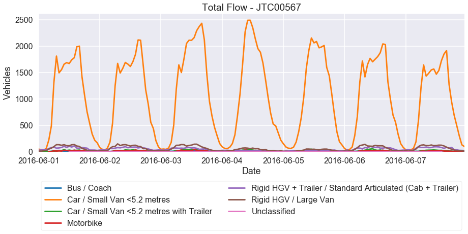

```python
# Set up the graph size
fig, ax = plt.subplots(figsize=(15, 5))

# Get the data for each class in the DataFrame
for vehicle_class, data in hourly_counts.groupby('Info'):
    # Plot the data for that class
    ax.plot_date(data['DateTime'], data['Count'], label=vehicle_class, linestyle='-', marker='')

# Set up legend
plt.legend(frameon=True, facecolor='white',
           loc='lower center', ncol=2, bbox_to_anchor=(0.5, -0.6))

# Set up axis labels
plt.xlabel('Date')
plt.ylabel('Vehicles')

# Fix margins properly
plt.ylim(bottom=0)
ax.margins(x=0)
plt.title('Total Flow - JTC00567')
```

- Suppose we want to plot both directions separately - we can do this using `subplots`

```
(0, 1582.3)
```

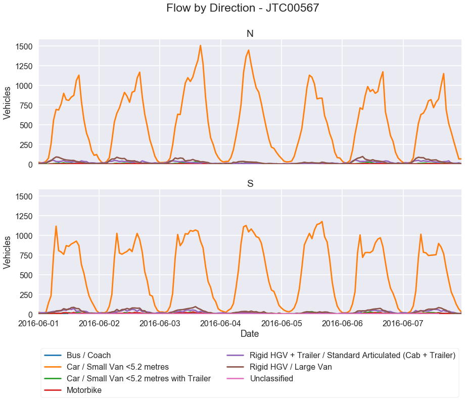

```python
# Set up the subplots
fig, all_axes = plt.subplots(2, figsize=(15, 10), sharex=True, sharey=True)

# Get the data for each class in the DataFrame
for i, (direction, directional_data) in enumerate(hourly_counts_d.groupby('Direction')):
    for vehicle_class, data in directional_data.groupby('Info'):
        # Plot the data for that class
        all_axes[i].plot_date(data['DateTime'], data['Count'], label=vehicle_class, linestyle='-', marker='')
        all_axes[i].margins(x=0)
        all_axes[i].set_title(direction)
        all_axes[i].set_ylabel('Vehicles')

# Set up legend
plt.legend(frameon=True, facecolor='white',
           loc='lower center', ncol=2, bbox_to_anchor=(0.5, -0.7))

# Set up labels
plt.xlabel('Date')
fig.suptitle('Flow by Direction - JTC00567')

# Fix margins properly
plt.ylim(bottom=0)
```

### Histograms

- Suppose we want to plot a histogram of the car speeds
- `pandas` includes a method that lets a `DataFrame` be exported as a histogram

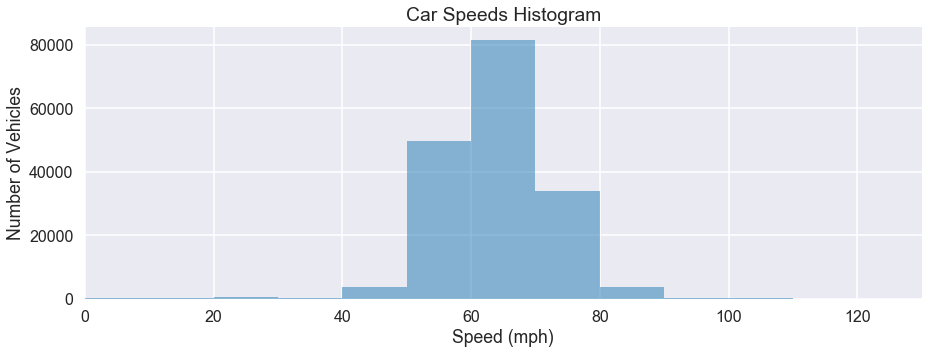

```python
# Set up the graph size
fig, ax = plt.subplots(figsize=(15, 5))

# Filter our original DataFrame to only contain cars (class 2)
cars = original_data[original_data['Class'] == '2']

# Set up the bins we want to use in our histogram
bin_size = 10
bins = range(0,max(cars['SpeedMPH']) + bin_size, bin_size)

# Plot the histogram
cars.hist(column='SpeedMPH', bins=bins, ax=ax, alpha=0.5)

# Set up labels and title
plt.xlabel('Speed (mph)')
plt.ylabel('Number of Vehicles')
plt.title('Car Speeds Histogram')

# Fix the margins
ax.margins(x=0)
```

### Heatmaps

- One of the advantages of `seaborn` over `matplotlib` is the ease with which heatmaps can be made
- We can simply provide the rows, columns and value we want to represent
- Suppose we want to create a heatmap of our car flows - each row representing a day and each column an hour
- We need to adjust our data into the correct format - first we'll filter to just cars and add in some nice columns for the date and time

```python
nb_cars = hourly_counts_d[(hourly_counts_d['Info'] == 'Car / Small Van <5.2 metres')  &
                              (hourly_counts_d['Direction'] == 'N')].copy()
nb_cars['Day'] = nb_cars['DateTime'].dt.weekday_name
nb_cars['Hour'] = nb_cars['DateTime'].dt.time#hour.astype('str')
nb_cars.head(15)
```

|  | DateTime | Info | Direction | Count | Day | Hour |
| --- | --- | --- | --- | --- | --- | --- |
| 0 | 2016-06-01 00:00:00 | Car / Small Van <5.2 metres | N | 26 | Wednesday | 00:00:00 |
| 7 | 2016-06-01 01:00:00 | Car / Small Van <5.2 metres | N | 19 | Wednesday | 01:00:00 |
| 15 | 2016-06-01 02:00:00 | Car / Small Van <5.2 metres | N | 19 | Wednesday | 02:00:00 |
| 23 | 2016-06-01 03:00:00 | Car / Small Van <5.2 metres | N | 38 | Wednesday | 03:00:00 |
| 31 | 2016-06-01 04:00:00 | Car / Small Van <5.2 metres | N | 79 | Wednesday | 04:00:00 |
| 43 | 2016-06-01 05:00:00 | Car / Small Van <5.2 metres | N | 256 | Wednesday | 05:00:00 |
| 54 | 2016-06-01 06:00:00 | Car / Small Van <5.2 metres | N | 561 | Wednesday | 06:00:00 |
| 66 | 2016-06-01 07:00:00 | Car / Small Van <5.2 metres | N | 696 | Wednesday | 07:00:00 |
| 78 | 2016-06-01 08:00:00 | Car / Small Van <5.2 metres | N | 688 | Wednesday | 08:00:00 |
| 90 | 2016-06-01 09:00:00 | Car / Small Van <5.2 metres | N | 767 | Wednesday | 09:00:00 |
| 102 | 2016-06-01 10:00:00 | Car / Small Van <5.2 metres | N | 900 | Wednesday | 10:00:00 |
| 114 | 2016-06-01 11:00:00 | Car / Small Van <5.2 metres | N | 818 | Wednesday | 11:00:00 |
| 126 | 2016-06-01 12:00:00 | Car / Small Van <5.2 metres | N | 811 | Wednesday | 12:00:00 |
| 139 | 2016-06-01 13:00:00 | Car / Small Van <5.2 metres | N | 852 | Wednesday | 13:00:00 |
| 151 | 2016-06-01 14:00:00 | Car / Small Van <5.2 metres | N | 874 | Wednesday | 14:00:00 |

- Next, we'll pivot this toget the days as rows and hours as columns.

```python
column_order = ['Sunday', 'Monday', 'Tuesday', 'Wednesday', 'Thursday', 'Friday', 'Saturday']

pivot = nb_cars.pivot(index='Day', columns='Hour', values='Count')
pivot = pivot.reindex_axis(column_order, axis=0)
pivot
```

| Hour Day | 00:00:00 | 01:00:00 | 02:00:00 | 03:00:00 | 04:00:00 | 05:00:00 | 06:00:00 | 07:00:00 | 08:00:00 | 09:00:00 | ... | 14:00:00 | 15:00:00 | 16:00:00 | 17:00:00 | 18:00:00 | 19:00:00 | 20:00:00 | 21:00:00 | 22:00:00 | 23:00:00 |
| --- | --- | --- | --- | --- | --- | --- | --- | --- | --- | --- | --- | --- | --- | --- | --- | --- | --- | --- | --- | --- | --- |
| Sunday | 74 | 39 | 30 | 32 | 41 | 101 | 215 | 325 | 453 | 701 | ... | 830 | 838 | 839 | 615 | 524 | 392 | 305 | 154 | 85 | 80 |
| Monday | 40 | 16 | 22 | 46 | 176 | 382 | 543 | 716 | 697 | 868 | ... | 924 | 1073 | 1173 | 667 | 523 | 363 | 291 | 151 | 81 | 48 |
| Tuesday | 22 | 19 | 20 | 23 | 82 | 305 | 515 | 631 | 649 | 709 | ... | 828 | 1001 | 1150 | 690 | 516 | 408 | 290 | 177 | 67 | 69 |
| Wednesday | 26 | 19 | 19 | 38 | 79 | 256 | 561 | 696 | 688 | 767 | ... | 874 | 1062 | 1130 | 797 | 561 | 397 | 309 | 174 | 114 | 124 |
| Thursday | 62 | 26 | 15 | 37 | 83 | 292 | 536 | 648 | 715 | 818 | ... | 927 | 1093 | 1168 | 861 | 635 | 482 | 313 | 212 | 102 | 43 |
| Friday | 20 | 23 | 24 | 33 | 77 | 242 | 475 | 635 | 631 | 839 | ... | 1226 | 1320 | 1507 | 1278 | 852 | 542 | 337 | 253 | 146 | 88 |
| Saturday | 48 | 29 | 36 | 37 | 85 | 186 | 351 | 531 | 756 | 1163 | ... | 970 | 914 | 775 | 613 | 461 | 320 | 218 | 202 | 151 | 108 |

7 rows × 24 columns

- From this data, creating a heatmap is very simple

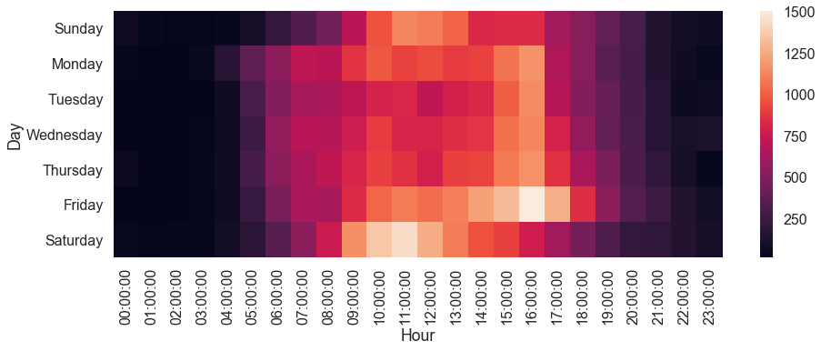

```python
# Set up the graph size
fig, ax = plt.subplots(figsize=(15, 5))

sns.heatmap(pivot)
```

- If we choose, we can annotate this heatmap with the counts

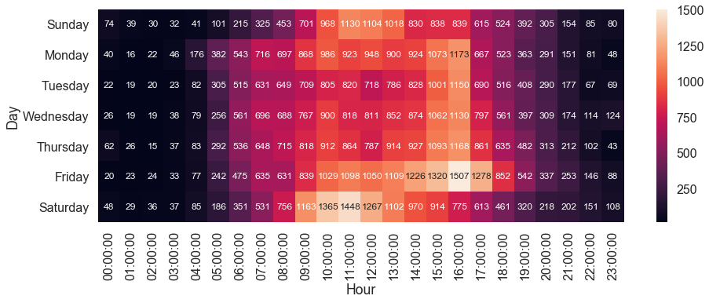

```python
# Set up the graph size
fig, ax = plt.subplots(figsize=(15, 5))

sns.heatmap(pivot, annot=True, fmt='d', annot_kws={'size': 12})
```

### Box and Whisker Plots

- Box and whisker plots are good for showing the distribution of data
- For this example, let's collect the data for every site observed
- As different sites use different classifications, we'll filter to car data only by using a partial match on the word "Car"

```python
import os

data_files = [f for f in os.listdir('VBV_Data') if f.startswith('VBV')]
all_data = pd.DataFrame()
for f in data_files:
    f_path = os.path.join('VBV_Data', f)
    data = pd.read_csv(f_path, low_memory=False)
    all_data = all_data.append(data)

all_cars = all_data[all_data['Info'].str.contains('Car')]
```

- Next, we again use seaborn directly to create a box plot

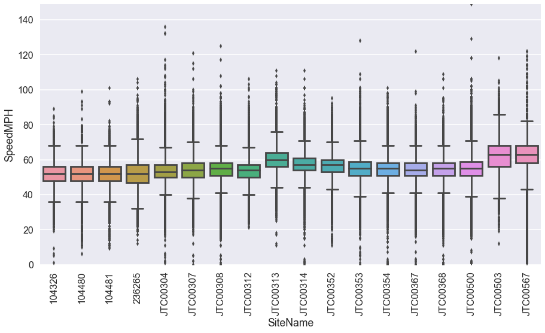

```python
# Set up the graph size
fig, ax = plt.subplots(figsize=(15, 8))

box_plot = sns.boxplot(data=all_cars, y='SpeedMPH', x='SiteName')

for lbl in box_plot.get_xticklabels():
    lbl.set_rotation(90)
ax.margins(y=0)
```